# Exercicios

## Exercícios – Erros em Medidas Experimentais

- 1.[Lilja 2000, 4.3]Por que nem sempre é razoável adotar um intervalo de confiança de 99%
- R: Provavelmente sera um intervalo de confiança muito largo, ou irá precisar muitos dados para tornar o intervalo confiança mais curto
- Pois significa que se repetíssemos o estudo inúmeras / infinitas vezes, em cada vez, fosse calculado o intervalo de confiança em 99% das vezes o valor estaria entre o intervalo de confiança

2 - [Lilja 2000, 4.4]Descreva as diferenças entre exatidão, resolução e precisão para um instrumentousado para medir comprimento, como uma fita métrica - exatidão a fita métrica mede 10cm, esses 10cm medidos são exatamente 10cm universais - resolução a escala da fita pode ser em cm ou mm - precisão, a fita métrica é 99% precisa para tamanhos de até 100cm

3.[Lilja 2000, 4.5]Qual é a principal diferença entre erro sistemático e erro aleatório? - erro aleatório pode acontecer de forma aleatória, indeterminísticos, pode ser devido à ferramenta, ou experimentos e no fim, afetam a precisão e consequentemente a repetibilidade - erro sistemático incorreção ou variação no processo experimental, pode ser controlado pelo experimentador #tende a introduzir lentidão constante, e também erros sistemáticos são devidos poderiam ser previstos ou encontrados com testes experimentais

- Intervalo mais largo é aquele que executou menos vezes
4. O tempo de processamento de requisições em um servidor foi mensurado, resultando nas se-guintes observações:

```r
tempos = c(92.2, 76.8, 7.3, 16.4, 32.5, 37.0, 41.6, 50.9, 62.6, 50.7, 34.6, 36.4)
#qnorm(tempos)
#prof

icr <- t.test(tempos, conf.level=0.9)
str(icr)
```

```
## List of 10
##  $ statistic  : Named num 6.52
##   ..- attr(*, "names")= chr "t"
##  $ parameter  : Named num 11
##   ..- attr(*, "names")= chr "df"
##  $ p.value    : num 4.32e-05
##  $ conf.int   : num [1:2] 32.5 57.3
##   ..- attr(*, "conf.level")= num 0.9
##  $ estimate   : Named num 44.9
##   ..- attr(*, "names")= chr "mean of x"
##  $ null.value : Named num 0
##   ..- attr(*, "names")= chr "mean"
##  $ stderr     : num 6.89
##  $ alternative: chr "two.sided"
##  $ method     : chr "One Sample t-test"
##  $ data.name  : chr "tempos"
##  - attr(*, "class")= chr "htest"
```

```r
xbar <- mean(tempos)
s <- sd(tempos)
e <- 0.06
z <-qnorm(0.975)
z
```

```
## [1] 1.959964
```

```r
nest <- (z*s/(e*xbar))^2
ceiling(nest)
```

```
## [1] 302
```

```r
# Tenfen
n <- length(tempos)
t.m <- mean(tempos)
t.v <- var(tempos)
t.ic <- t.m + qt(c(0.050, 0.950), df = n-1) * sqrt(t.v/n)
t.ic
```

```
## [1] 32.54014 57.29320
```

```r
t.test(tempos, conf.level=0.9)
```

```
##
##  One Sample t-test
##
## data:  tempos
## t = 6.5176, df = 11, p-value = 4.322e-05
## alternative hypothesis: true mean is not equal to 0
## 90 percent confidence interval:
##  32.54014 57.29320
## sample estimates:
## mean of x
##  44.91667
```

1. Baseado nessa amostra, calcule o intervalo de confiança de 90% para a média.
- R: 32.5401382, 57.2931952
2. Determine a quantidade de medições necessárias para obter, com 95% de confiança, otempo médio de processamento com uma margem de erro de±6%.

```r
prop.test(22, 80, conf.level=0.99)
```

```
##
##  1-sample proportions test with continuity correction
##
## data:  22 out of 80, null probability 0.5
## X-squared = 15.312, df = 1, p-value = 9.111e-05
## alternative hypothesis: true p is not equal to 0.5
## 99 percent confidence interval:
##  0.1625073 0.4235501
## sample estimates:
##     p
## 0.275
```

```r
prop.test(22000, 80000, conf.level=0.99)
```

```
##
##  1-sample proportions test with continuity correction
##
## data:  22000 out of 80000, null probability 0.5
## X-squared = 16199, df = 1, p-value < 2.2e-16
## alternative hypothesis: true p is not equal to 0.5
## 99 percent confidence interval:
##  0.2709462 0.2790912
## sample estimates:
##     p
## 0.275
```

```r
# 0.275 média análisada
0.275*80 # > 10 para ser valido
```

```
## [1] 22
```

```r
(1 - 0.275) * 80 # > 10
```

```
## [1] 58
```

- 5. Um DBA analisou um conjunto de 80 consultas a um banco de dados e observou que 22 delasenvolviam quatro tabelas.
1. Determine o intervalo de confiança de 99% para a proporção de consultas que envolvemquatro tabelas.
2. O que aconteceria (qualitativa e quantitativamente) com o intervalo de confiança se a mesmaproporção tivesse sido observada em um conjunto de 80.000 consultas?

```r
consultas <- read.table("texec.txt", header = TRUE)
summary(consultas)
```

```
##        te
##  Min.   :60.00
##  1st Qu.:69.00
##  Median :71.00
##  Mean   :71.64
##  3rd Qu.:74.00
##  Max.   :85.00
```

```r
texec <- consultas$te

xbar <- mean(texec)
s <- sd(texec)
z <- qnorm(0.9)
n <- length(texec)

# na mao
xbar + c(-1, 1)*s*z/sqrt(n)
```

```
## [1] 71.28791 71.99209
```

```r
# func
t.test(texec, conf.level=0.8)
```

```
##
##  One Sample t-test
##
## data:  texec
## t = 260.76, df = 199, p-value < 2.2e-16
## alternative hypothesis: true mean is not equal to 0
## 80 percent confidence interval:
##  71.28674 71.99326
## sample estimates:
## mean of x
##     71.64
```

```r
t.test(texec, conf.level=0.999)
```

```
##
##  One Sample t-test
##
## data:  texec
## t = 260.76, df = 199, p-value < 2.2e-16
## alternative hypothesis: true mean is not equal to 0
## 99.9 percent confidence interval:
##  70.72236 72.55764
## sample estimates:
## mean of x
##     71.64
```

6. O arquivo de dadostexec.txtcontém medições de tempo de execução de umbenchmarkem umsistema. Calcule intervalos de confiança de 80% e 99,9% para a média do tempo de execução.

```r
bechmark = read.table("rtt.txt", header = TRUE)
summary(bechmark)
```

```
##       RTT
##  Min.   : 227
##  1st Qu.: 287
##  Median : 317
##  Mean   : 421
##  3rd Qu.: 527
##  Max.   :1353
```

```r
rtt <- bechmark$RTT

t.test(rtt, conf.level=0.95)
```

```
##
##  One Sample t-test
##
## data:  rtt
## t = 65.04, df = 969, p-value < 2.2e-16
## alternative hypothesis: true mean is not equal to 0
## 95 percent confidence interval:
##  408.2924 433.6973
## sample estimates:
## mean of x
##  420.9948
```

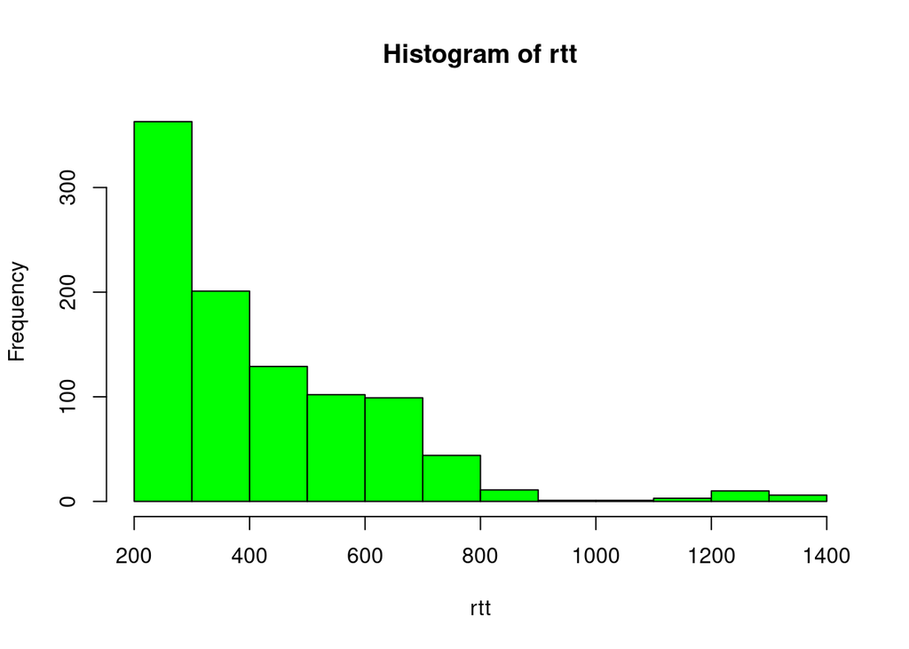

```r
hist(rtt, col = "GREEN")
```

7. O arquivo de dadosrtt.txtcontém medições de RTT (round-trip time) entre um cliente e umservidor na Internet
1. Calcule o intervalo de confiança de 95% para a média do RTT
2. Gere o histograma das medições de RTT, e discuta se é razoável supor que 95% dos inter-valos de confiança conterão a média do RTT. R: sim

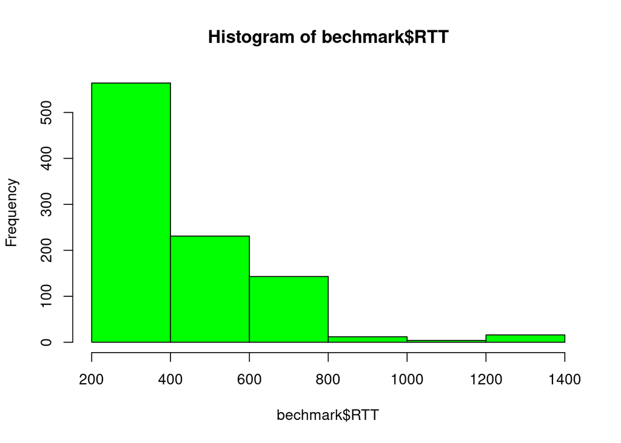

```r
hist(bechmark$RTT, col = "GREEN", breaks=5)
```